# Midterm: Spring 2023

Author

Brittany Lane

Consider the [college scorecard data (**college**)](https://search.r-project.org/CRAN/refmans/SDAResources/html/college.html) from the `SDAResources` package.

```r
library(tidyverse)
library(SDAResources)
data(college)
```

## 1. Find the population average price of attendance for college (*npt4*).

```r
m = mean(college$npt4, na.rm = TRUE)
```

Mean: 20187.2164

## 2. Let’s focus on simple random sampling.

### 2a. Take a simple random sample of 250 colleges.

```r
set.seed(7581)
cosamp <- college%>% slice_sample(n=250)
head(cosamp, n=5)
```

```
# A tibble: 5 × 29
  unitid instnm city  stabbr highdeg control region locale ccbasic ccsiz…¹  hbcu
   <dbl> <chr>  <chr> <chr>    <dbl>   <dbl>  <dbl>  <dbl>   <dbl>   <dbl> <dbl>
1 193973 Niaga… Niag… NY           4       2      2     21      18      13     0
2 199111 Unive… Ashe… NC           4       1      5     13      21      13     0
3 151324 India… Terr… IN           4       1      3     13      17      16     0
4 154235 Saint… Dave… IA           4       2      4     12      18      11     0
5 125727 Westm… Sant… CA           3       2      8     22      21      11     0
# … with 18 more variables: openadmp <dbl>, adm_rate <dbl>, sat_avg <dbl>,
#   ugds <dbl>, ugds_men <dbl>, ugds_women <dbl>, ugds_white <dbl>,
#   ugds_black <dbl>, ugds_hisp <dbl>, ugds_asian <dbl>, ugds_other <dbl>,
#   npt4 <dbl>, tuitionfee_in <dbl>, tuitionfee_out <dbl>, avgfacsal <dbl>,
#   pftfac <dbl>, c150_4 <dbl>, grads <dbl>, and abbreviated variable name
#   ¹ccsizset
```

### 2b. Estimate the average price of attendance for college (*npt4*); remember to include both the point and interval estimates.

```r
cosamp %>% summarize( # request summary statistics
  mean = mean(npt4, na.rm = TRUE), # request the mean
  var = var(npt4, na.rm = TRUE) # request the variance
  )  # note: the na.rm = TRUE excludes missing from calculation
```

```
# A tibble: 1 × 2
    mean       var
   <dbl>     <dbl>
1 20457. 51253279.
```

```r
# set values to use in computation:
m = mean(cosamp$npt4, na.rm = TRUE) # find the mean of npt4
s2 = var(cosamp$npt4, na.rm = TRUE) # find the variance of npt4
n = nrow(cosamp) # count the number of rows for sample size
N = nrow(college) # count the number of rows for population size

# computations:
estvar = (1-n/N)*s2/n # find the estimated variance
SE = sqrt(estvar) # find the SE
CV = SE/m

t = qt(.975, n-1)
tau_hat = N*m
estvar = N^2*(1-n/N)*s2/n # find the estimated variance
SE = sqrt(estvar) # find the SE
lb = tau_hat - t*SE
ub = tau_hat + t*SE
```

m = 20456.588 Se: 561777.4555 Tau_hat: 28066438.736 Lb: 26959997.3259 UB: 29172880.1461

## 3. Let’s focus on stratified sampling.

### 3a. Stratify by the cross-classification of *control* (1 = public, 2 = private) and *highdeg* (highest degree awarded; 3 = Bachelor’s, 4 = Graduate) Create a new variable identifying the strata.

```r
college <- college %>%
  mutate(strata = case_when(
    control == 1 & highdeg == 3 ~ 1,
    control == 1 & highdeg == 4 ~ 2,

    control == 2 & highdeg == 3 ~ 3,
    control == 2 & highdeg == 4~ 4,



  ))
```

### 3b. Count the number of colleges in each stratum.

```r
col_strat <- college %>% count(strata)
```

### 3c. Suppose a sample of 250 colleges is to be taken. Find the sample size for each of the strata under proportional allocation.

```r
N = sum(col_strat$n)

col_strat <- col_strat %>%
  mutate(ph = (n/N)) %>%
  mutate(n_h = ceiling(250*ph))
```

### 3d. We think that the variance will be proportional to the variance of the number of undergraduates (*ugds*). Calculate the variance for number of undergrads for each stratum.

```r
col_und <- college %>%
  group_by(strata) %>%
  summarize(var= var(ugds),
            n = n())

summary <- college %>%
  group_by(strata) %>%
  summarize(N = n())

summaries <- full_join(summary, col_und, by = "strata")
```

### 3e. Use the variances found in question 3d to find the Neyman allocation.

```r
summaries_allo <- full_join(summaries, col_strat, by = "strata")

summaries_allo<- summaries_allo %>%
  mutate(a_num = N*sqrt(var)) %>%
  mutate(a = a_num/sum(a_num)) %>%
  mutate(n_allocation = a * 250)



head(summaries_allo)
```

```
# A tibble: 4 × 10
  strata     N       var   n.x   n.y     ph   n_h    a_num       a n_allocation
   <dbl> <int>     <dbl> <int> <int>  <dbl> <dbl>    <dbl>   <dbl>        <dbl>
1      1    25  6803247.    25    25 0.0182     5   65208. 0.00787         1.97
2      2   475 96055100.   475   475 0.346     87 4655366. 0.562         140.
3      3   173  8110015.   173   173 0.126     32  492671. 0.0594         14.9
4      4   699 19347662.   699   699 0.509    128 3074620. 0.371          92.7
```

### 3f. Take a stratified sample based on the proportional allocation above.

```r
p1<- college %>% filter(strata==1) %>% slice_sample(n=5)
p2<- college %>% filter(strata==2) %>% slice_sample(n=87)
p3<- college %>% filter(strata==3) %>% slice_sample(n=32)
p4<- college %>% filter(strata==4) %>% slice_sample(n=128)

pt_summary<- rbind(p1,p2,p3,p4)
```

```r
st1<- college %>% filter(strata==1) %>% slice_sample(n=2)
st2<- college %>% filter(strata==2) %>% slice_sample(n=112)
st3<- college %>% filter(strata==3) %>% slice_sample(n=12)
st4<- college %>% filter(strata==4) %>% slice_sample(n=74)

st_summary<- rbind(st1,st2,st3,st4)
```

### 3h. Estimate the average price of attendance for college (*npt4*) using your sample from question 3f. Remember to construct both the point estimate and the interval estimate.

```r
# set values to use in computation:
m = mean(pt_summary$npt4, na.rm = TRUE) # find the mean of acres92
s2 = var(pt_summary$npt4, na.rm = TRUE) # find the variance of acres92
n = nrow(pt_summary) # count the number of rows for sample size
N = nrow(college) # count the number of rows for population size

# computations:
estvar = (1-n/N)*s2/n # find the estimated variance
SE = sqrt(estvar) # find the SE
CV = SE/m

t.test(pt_summary$npt4, conf.level = 0.95)
```

```
    One Sample t-test

data:  pt_summary$npt4
t = 43.48, df = 251, p-value < 2.2e-16
alternative hypothesis: true mean is not equal to 0
95 percent confidence interval:
 18954.87 20753.50
sample estimates:
mean of x
 19854.19
```

LB:18954.87 UB: 20753.50

mean: 19854.19

### 3i. Estimate the average price of attendance for college (*npt4*) using your sample from question 3g. Remember to construct both the point estimate and the interval estimate.

```r
ney_allo <- college %>%
  group_by(strata) %>%
  summarize(mean = mean(npt4),
            var = var(npt4, na.rm = TRUE), # request variance
            n = n()) # request sample size

summary<- college %>%
  group_by(strata) %>%
  summarize(N = 1372)



summaries <- full_join(ney_allo, summary, by = "strata")


summaries <- summaries %>% # estimate the mean
  mutate(ybar = N/sum(N)*mean)
sum(summaries$ybar, na.rm=TRUE)
```

```
[1] 17982.2
```

```r
summaries<- summaries %>% #estimate the variance(ystr)
  mutate(varhat_ybar = (1-n/N)*(N^2/sum(N, na.rm = TRUE)^2)*(var/n))
sum(summaries$varhat_ybar, na.rm = TRUE)
```

```
[1] 37202.82
```

```r
#confidence interval
# set values to use in computation:
m_ney = sum(summaries$ybar) # point estimate for mu
estvar = sum(summaries$varhat_ybar) # find the variance of ybar
SE = sqrt(estvar) # find the SE
n = sum(summaries$n) # find overall sample size
H = nrow(summaries) # count the number of rows for number of strata
t = qt(.975, n)

# CI computations:
lb = m_ney - t*SE
ub = m_ney + t*SE

lb # print lower bound of CI
```

```
[1] 17603.82
```

```r
ub
```

```
[1] 18360.57
```

m_ney: 17982.1961 SE: 192.8803 Lb: 17603.82 UB: 18360.57

## 4. Let’s focus on cluster sampling.

### 4a. Let’s use states as clusters. Take a sample of five (5) states.

```r
library(datasets)
states <- state.abb
set.seed(970517510) # use your student number as your seed
sample(states, 5)
```

```
[1] "NJ" "IA" "LA" "ME" "AL"
```

### 4b. Estimate the average price of attendance for college (*npt4*); remember to include both the point and interval estimates.

```r
clg <- college %>%
  group_by(stabbr) %>%
  summarize(y_bar_i = mean(npt4),
            tau_i = sum(npt4),
            Mi = n())

(y_bar_r = sum(clg$Mi*clg$y_bar_i)/sum(clg$Mi))
```

```
[1] 20187.22
```

```r
n = nrow(clg)
N = nrow(college)
Mbar = sum(clg$Mi)/n
s_r2 = sum(clg$Mi^2*(clg$y_bar_i-y_bar_r)^2)/(n-1)
(SE = sqrt((1-n/N)*(s_r2/(n*Mbar^2))))
```

```
[1] 489.6711
```

```r
MOE = qt(0.975, n-1)*SE
(lcl = y_bar_r - MOE)
```

```
[1] 19203.68
```

```r
(ucl = y_bar_r + MOE)
```

```
[1] 21170.75
```

### 5a. Take a 1 in 5 sample.

```r
getsys = function(k,N){
  n = ceiling(N/k)
  r = sample(1:k, 1)
  seq(r, r + k*(n-1), k)
}


# example use - penguin dataset with k = 5
#sample <- palmerpenguins::penguins[getsys(k = 5, N = nrow(palmerpenguins::penguins)), ]
```

### 5b. Estimate the average price of attendance for college (*npt4*); remember to include both the point and interval estimates.

```r
sample5 <- college[getsys(k = 5, N = nrow(college)), ]
mean = mean(sample5$npt4, na.rm=TRUE)
t.test(sample5$npt4, conf.level = 0.95)
```

```
    One Sample t-test

data:  sample5$npt4
t = 45.166, df = 274, p-value < 2.2e-16
alternative hypothesis: true mean is not equal to 0
95 percent confidence interval:
 19445.96 21218.43
sample estimates:
mean of x
  20332.2
```

Mean: 20332.2 LB: 19445.96 UB: 21218.43 ## 6. Let’s compile our results.

### 6a. Create a table showing the results from each sampling scheme.

[output not shown]

### 6b. Construct a data visualization corresponding to the table above.

```r
install.packages("scales",  repos = "http://cran.us.r-project.org")
library("scales")
df <- data.frame(method=c("None", "Simple", "Proportional", "Neyman", "Cluster", "Systematic"),
                 mean=c(20187.22,20456.59,19854.19,17982.19, 20187.22, 20045.5),
                 lower=c(0, 26959997.32,18954.87,17603.82,19203.68,19220.07),
                 upper=c(0,29172880.15,20753.50, 18360.57, 21170.75,20870.93 )
                )

head(df)
```

```
        method     mean       lower       upper
1         None 20187.22        0.00        0.00
2       Simple 20456.59 26959997.32 29172880.15
3 Proportional 19854.19    18954.87    20753.50
4       Neyman 17982.19    17603.82    18360.57
5      Cluster 20187.22    19203.68    21170.75
6   Systematic 20045.50    19220.07    20870.93
```

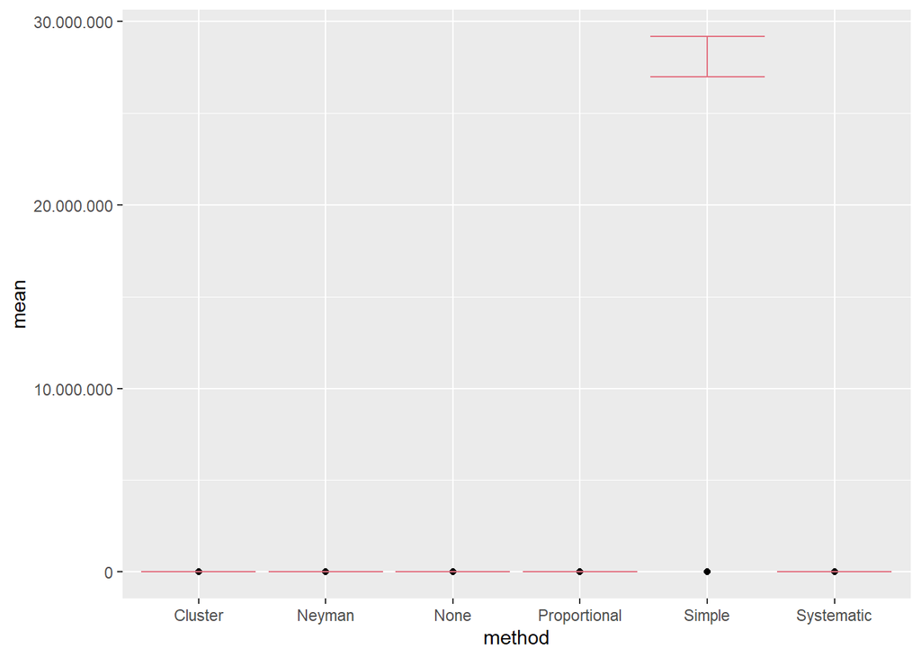

```r
df %>%

ggplot(aes(x = method, y = mean)) +
   scale_y_continuous(labels = comma_format(big.mark = ".",
                                           decimal.mark = ","))+
geom_point(fill="#69b3a2", color="#000000") +
  geom_errorbar(aes(ymin= lower, ymax = upper), color= "#E37383")
```